# Fama-French三因素模型（一）

## 多因子打分模型回顾

**所选因子：**

[figure not shown]

- 股票池：沪深300
- 打分规则：个股在每个因子上的排名求算术平均（因子等权重）
- 股票选取：得分排名最高的10只
- 调仓频率：月度

[figure not shown]

```python
#获取多因子模型收益率
MultiFactor=rqportal.portfolio(1604099).daily_returns.values
```

```python
len(HML)==len(SMB)==len(RM)==len(MultiFactor)
```

```
True
```

```python
#回归分析
import statsmodels.api as sm
```

```python
X=np.column_stack((HML,SMB,RM))
y=MultiFactor
```

```python
X1 = sm.add_constant(X)
```

```python
model = sm.OLS(y, X1)
results = model.fit()
```

```python
results.summary()
```

OLS Regression Results

| Dep. Variable: | y | R-squared: | 0.867 |
| --- | --- | --- | --- |
| Model: | OLS | Adj. R-squared: | 0.867 |
| Method: | Least Squares | F-statistic: | 3170. |
| Date: | Fri, 12 May 2017 | Prob (F-statistic): | 0.00 |
| Time: | 13:07:10 | Log-Likelihood: | 5439.8 |
| No. Observations: | 1458 | AIC: | -1.087e+04 |
| Df Residuals: | 1454 | BIC: | -1.085e+04 |
| Df Model: | 3 |  |  |
| Covariance Type: | nonrobust |  |  |

|  | coef | std err | t | P>\|t\| | [95.0% Conf. Int.] |
| --- | --- | --- | --- | --- | --- |
| const | 0.0004 | 0.000 | 2.830 | 0.005 | 0.000 0.001 |
| x1 | 0.1353 | 0.018 | 7.677 | 0.000 | 0.101 0.170 |
| x2 | 0.3383 | 0.014 | 24.260 | 0.000 | 0.311 0.366 |
| x3 | 0.8851 | 0.010 | 90.903 | 0.000 | 0.866 0.904 |

| Omnibus: | 142.737 | Durbin-Watson: | 1.913 |
| --- | --- | --- | --- |
| Prob(Omnibus): | 0.000 | Jarque-Bera (JB): | 393.667 |
| Skew: | 0.522 | Prob(JB): | 3.28e-86 |
| Kurtosis: | 5.322 | Cond. No. | 133. |

可以看到，回归系数在统计上(95%置信度)都不为0

```python
paras=results.params
```

```python
y_predic=np.dot(X1,paras)
```

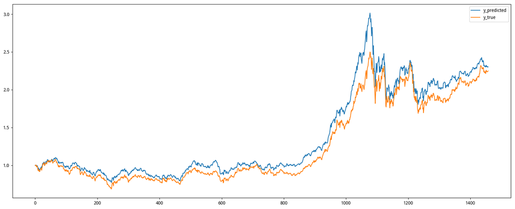

```python
plt.figure(figsize=[20,8])
plt.plot(np.cumprod(y_predic+1))
plt.plot(np.cumprod(y+1))
plt.legend(['y_predicted','y_true'])
```

此次分享到此为止，后续会基于三因子模型进行风险分解与评估，甚至将三因子模型扩展到五因子模型，敬请期待！

## 残差风险计算

由前文可知存在如下分解：$$E(R_{i}) - R_f = β(E(R_m) - R_f)+ sSMB+ hHMI$$

与之对应的回归式为：$$r_i=\alpha +\beta r_{mi}+s smb_i+h hmi_i+u_i$$

波动率分解：$$\sigma_r^2=cov(\beta r_{mi}+s smb_i+h hmi_i+u_i,\beta r_{mi}+s smb_i+h hmi_i+u_i)$$ $$\sigma_r^2=cov(\beta r_{mi}+s smb_i+h hmi_i,\beta r_{mi}+s smb_i+h hmi_i)+\sigma_u^2$$

我们主要关注残差风险(不可解释的风险来源)，即$\frac{\sigma_u}{\sigma_r}$

```python
print(u'残差风险占比为%f'%(np.std(y_predic-y)/np.std(y)))
```

```
残差风险占比为0.364165
```